# Reproducible Research: Peer Assessment 1

## 1. Loading and preprocessing the data

```r
activity <- read.csv("activity.csv", header = TRUE, sep = ",", quote = "\"",
                     dec = ".", fill = TRUE, comment.char = "")
```

## 2. What is mean total number of steps taken per day?

2.1. Calculate the total number of steps taken per day

```r
total_per_day <- aggregate(steps ~  date, data = activity,
                           FUN = sum, na.rm = TRUE)
```

2.2. Histogram of the total number of steps taken each day

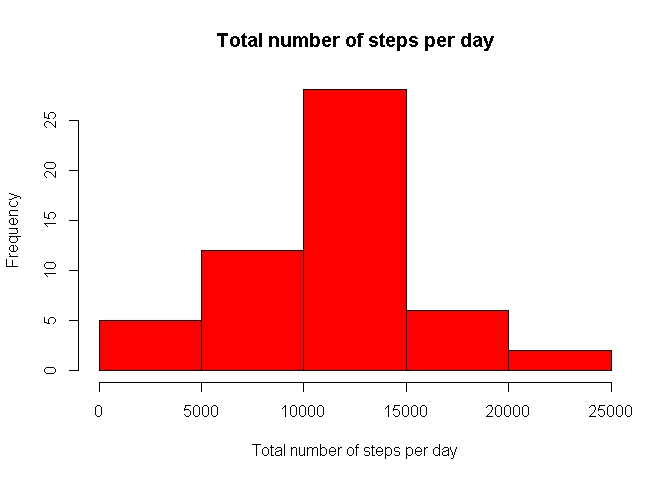

```r
hist(total_per_day$steps, freq = TRUE,  col = "red", border = NULL,
     main = "Total number of steps per day",
     xlab = "Total number of steps per day",
     axes = TRUE
)
```

```r
mean_of_total_per_day <-  mean(total_per_day$steps, trim = 0, na.rm = FALSE)
median_of_total_per_day <- median(total_per_day$steps, na.rm = FALSE)
```

## 3. What is the average daily activity pattern?

```r
average_per_interval <- aggregate(steps ~  interval, data = activity,
                           FUN = mean, na.rm = TRUE)
```

3.1. Make a time series plot (i.e. type = “l”) of the 5-minute interval (x-axis) and the average number of steps taken, averaged across all days (y-axis)

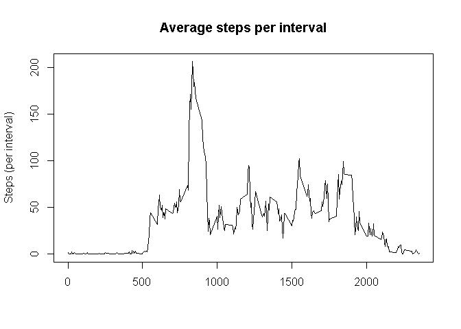

```r
plot(average_per_interval$interval, average_per_interval$steps,
     main = "Average steps per interval",
     type = "l",
     ylab = "Steps (per interval)",
     xlab = ""
)
```

3.2. Which 5-minute interval, on average across all the days in the dataset, contains the maximum number of steps?

```r
average_per_interval$interval[which.max(average_per_interval$steps)]
```

```
## [1] 835
```

## 4. Imputing missing values

4.1. Calculate and report the total number of missing values in the dataset (i.e. the total number of rows with NAs)

```r
length(activity$steps[is.na(activity$steps) == TRUE])
```

```
## [1] 2304
```

4.2. Strategy - filling in missing values with rounded mean for that 5-minute interval

Create a new dataset that is equal to the original dataset but with the missing data filled in.

```r
aa <- merge(activity, average_per_interval, by = "interval", sort = FALSE)

aa$steps <- aa$steps.x
aa$steps[is.na(aa$steps.x) == TRUE] <-
    round(aa$steps.y[is.na(aa$steps.x) == TRUE])

aa <- aa[order(aa$date, aa$interval),]

imputed_activity <- aa[ ,c("date", "interval", "steps")]
rownames(imputed_activity) <- NULL
#rm(aa)
```

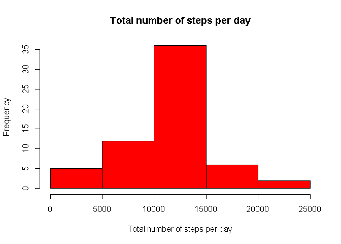

```r
total_per_day_i <- aggregate(steps ~  date, data = imputed_activity,
                           FUN = sum, na.rm = TRUE)

hist(total_per_day_i$steps, freq = TRUE,  col = "red", border = NULL,
     main = "Total number of steps per day",
     xlab = "Total number of steps per day",
     axes = TRUE
)
```

```r
mean_of_total_per_day_i <-  mean(total_per_day_i$steps, trim = 0, na.rm = FALSE)
median_of_total_per_day_i <- median(total_per_day_i$steps, na.rm = FALSE)
```

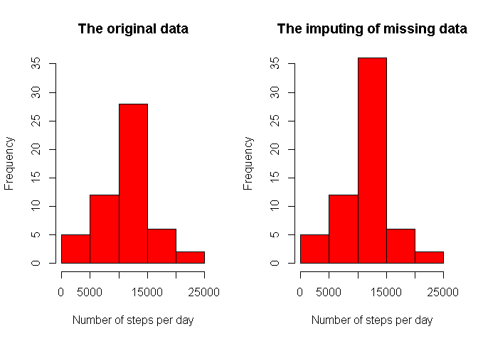

```r
par(mfrow = c(1, 2))

hist(total_per_day$steps, freq = TRUE,  col = "red", border = NULL,
     main = "The original data",
     xlab = "Number of steps per day",
     ylim = c(0,35),
     axes = TRUE
)

hist(total_per_day_i$steps, freq = TRUE,  col = "red", border = NULL,
     main = "The imputing of missing data",
     xlab = "Number of steps per day",
     ylim = c(0,35),
     axes = TRUE
)
```

## 5. Are there differences in activity patterns between weekdays and weekends?

5.1. Create a new factor variable in the dataset with two levels – “weekday” and “weekend” indicating whether a given date is a weekday or weekend day.

```r
library(lubridate)

aa$wd0 <- wday(as.Date(aa$date),  label = FALSE, abbr = TRUE)

activity$wd <- "weekday"
activity$wd[wday(as.Date(activity$date),  label = FALSE) == 7] <- "weekend"
activity$wd[wday(as.Date(activity$date),  label = FALSE) == 1] <- "weekend"

activity$wd <- as.factor(activity$wd)

class(activity$wd)
```

```
## [1] "factor"
```

5.2. Make a panel plot containing a time series plot (i.e. type = “l”) of the 5-minute interval (x-axis) and the average number of steps taken, averaged across all weekday days or weekend days (y-axis). See the README file in the GitHub repository to see an example of what this plot should look like using simulated data.

```r
average_per_interval_wday <- aggregate(steps ~  interval,
            data = activity[which(activity$wd == "weekday"), ],
            FUN = mean, na.rm = TRUE
            )
average_per_interval_wend <- aggregate(steps ~  interval,
           data = activity[which(activity$wd == "weekend"), ],
           FUN = mean, na.rm = TRUE
            )
```

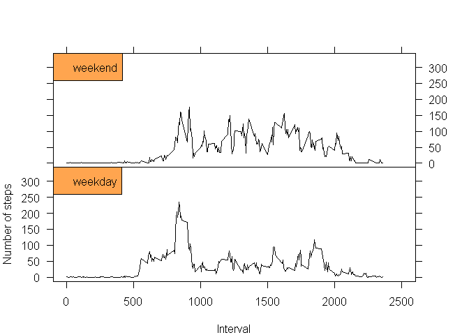

```r
par(mfrow = c(2, 1) )

par(mar = c(0, 4, 4, 4)   )
plot(average_per_interval_wend$interval, average_per_interval_wend$steps
     # , main = "weekend"
     , type = "l"
     , axes = FALSE
     , xlim = c(0,2500)
     , ylim = c(0,330)
      , ylab = ""
      , xlab = ""
)
axis(2, labels = FALSE); axis(3, labels = FALSE)
par(ann = TRUE); axis(4, las = 2); box(which = "plot", lty = "solid")
legend("topleft", bg = "tan1", legend = "weekend", inset = 0)

par(mar = c(4, 4, 0, 4)   )
plot(average_per_interval_wday$interval, average_per_interval_wday$steps
     # , main = "weekday"
     , type = "l"
     , axes = FALSE
     , xlim = c(0,2500)
     , ylim = c(0,330)
     , ylab = "Number of steps"
     , xlab = "Interval"
)
axis(1); axis(2, las = 2)
axis(4, labels = FALSE); box(which = "plot", lty = "solid")
legend("topleft", bg = "tan1", legend = "weekday", inset = 0)
```